# FRVT 1:1 Verification

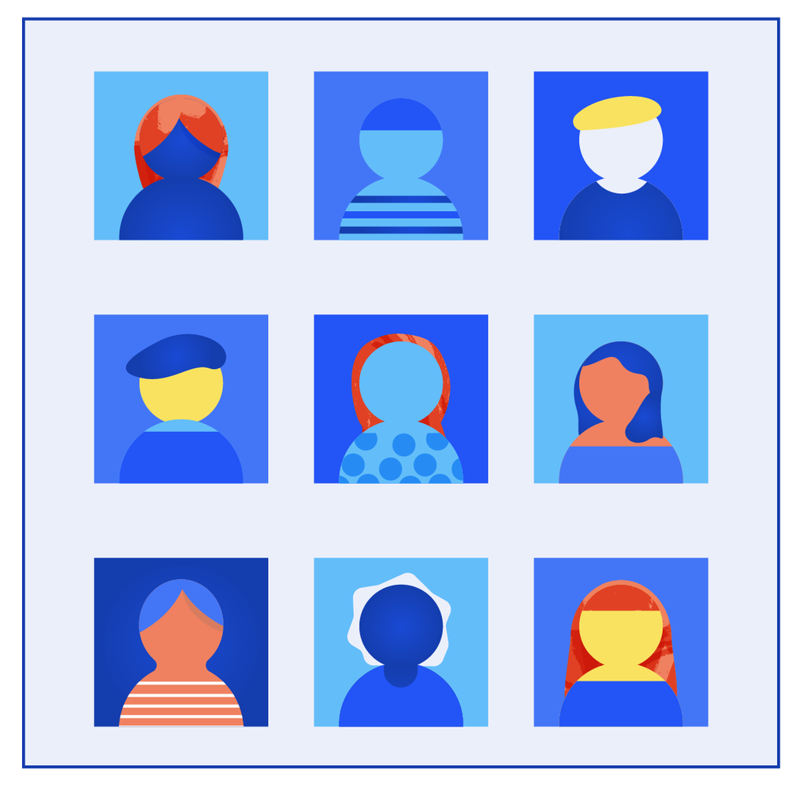

Credit: Natasha Hanacek/NIST

[Latest Report](https://pages.nist.gov/frvt/reports/11/frvt_11_report.pdf) | [Participation Agreement](https://pages.nist.gov/frvt/agreements/frvt_participation_agreement.pdf) | [API](https://pages.nist.gov/frvt/api/FRVT_ongoing_11_api.pdf) | [Validation](https://github.com/usnistgov/frvt) | [Encryption](https://www.nist.gov/itl/iad/image-group/products-and-services/encrypting-softwaredata-transmission-nist)

[last updated: 2024-08-12]

[output not shown]

[last updated: 2024-08-09]

###### False Positive Demographics

### False Positive Differentials

The table includes summary indicators for false positive demographic effects i.e. incorrect associations of two photos of two different individuals, the rate of which differs by age, sex or race. False positives occur primarily due to anatomic similarity of the faces and this occurs in images of pristine quality. False positives can in principle occur also due to image artifacts, such as reflections or eye-glasses, but these are specific to particular recognition algorithms.  
FMR values are measured over comparisons of two high quality frontal portrait images of two people of the same sex, same age group, and same region of birth. The threshold is fixed for each algorithm to give FMR if 0.0003 overall.

**A note on 1:N** While this table lists results for 1:1 algorithms, it will have relevance to that subset of 1:N algorithms that implement 1:N search as N 1:1 comparisons followed by a sort operation. The demographic effects noted here will be material in 1:N operations and will be magnified if the gallery and the search stream include the affected demographic. This is discussed in the Annex, and in the academic literature [PDF](https://www.dhs.gov/sites/default/files/publications/21_0922_st_quantifying-commercial-face-recognition-gender-and-race_updated.pdf), [PDF](https://openaccess.thecvf.com/content/ICCV2021W/RPRMI/papers/Drozdowski_The_Watchlist_Imbalance_Effect_in_Biometric_Face_Identification_Comparing_Theoretical_ICCVW_2021_paper.pdf). Note those publications use the Binomial model of 1:N search and it is known that some 1:N algorithms do not implement 1:N simply as N 1:1 comparisons, so the model does not apply. Demographic effects there must be measured in separate empiricial 1:N tests.

| Algorithm | Submission Date | FNMR Overall | FMR Min | FMR Max | FMR Max/Min | FMR Max/Mean | FMR Max/GeoMean | FMR Vary GeoMean | FMR Vary Gini | FMR_Ratio WAfrica EEurope | FMR_Ratio EAsia EEurope | FMR_Ratio SAsia EEurope | FMR_Ratio Female Male | FMR_Ratio Old Young |
| --- | --- | --- | --- | --- | --- | --- | --- | --- | --- | --- | --- | --- | --- | --- |
| recognito_001 | 2023-09-27 | 0.0013(1) | 0.00001 E.Europe M (20-35] | 0.01878 W.Africa F (65-99] | 3304(532) | 15.28(500) | 78.91(536) | 0.67(536) | 0.79(536) | 79.10(546) | 36.99(546) | 18.28(551) | 1.82(27) | 24.68(534) |
| qazsmartvisionai_001 | 2024-05-21 | 0.0013(2) | 0.00017 E.Europe M (20-35] | 0.02402 W.Africa F (65-99] | 139(31) | 11.26(290) | 21.00(148) | 0.35(13) | 0.59(76) | 6.95(75) | 2.90(112) | 2.73(72) | 2.61(88) | 5.23(414) |
| recognito_000 | 2023-05-24 | 0.0014(3) | 0.00001 E.Europe M (20-35] | 0.02113 W.Africa F (65-99] | 3897(534) | 15.89(517) | 75.02(534) | 0.65(534) | 0.78(532) | 84.66(549) | 38.95(548) | 18.79(552) | 1.85(31) | 21.31(530) |
| qazsmartvisionai_000 | 2024-01-11 | 0.0015(4) | 0.00008 E.Europe M (35-50] | 0.01282 W.Africa F (65-99] | 155(42) | 9.29(117) | 16.66(47) | 0.38(25) | 0.56(27) | 8.81(111) | 4.26(166) | 3.04(94) | 3.24(237) | 3.31(175) |
| cloudwalk_mt_007 | 2023-02-21 | 0.0015(5) | 0.00012 E.Europe M (20-35] | 0.00710 W.Africa F (65-99] | 60(7) | 8.22(60) | 13.05(22) | 0.32(6) | 0.51(9) | 3.21(23) | 1.06(3) | 1.62(21) | 2.17(47) | 6.12(457) |
| cloudwalk_mt_006 | 2022-10-20 | 0.0015(6) | 0.00014 E.Europe M (20-35] | 0.00917 W.Africa F (65-99] | 65(12) | 8.58(73) | 13.62(27) | 0.31(5) | 0.52(10) | 3.50(27) | 1.11(6) | 1.71(24) | 2.27(57) | 5.49(433) |
| cloudwalk_mt_005 | 2022-03-29 | 0.0015(7) | 0.00013 E.Europe M (20-35] | 0.01997 W.Africa F (65-99] | 150(39) | 10.08(189) | 20.67(139) | 0.41(62) | 0.62(246) | 2.80(14) | 0.61(47) | 2.84(78) | 3.05(169) | 8.24(487) |
| sensetime_007 | 2022-06-17 | 0.0015(8) | 0.00004 E.Europe M (20-35] | 0.01565 W.Africa F (65-99] | 402(249) | 13.84(467) | 34.43(440) | 0.46(289) | 0.67(434) | 10.20(138) | 1.47(39) | 5.76(492) | 3.35(271) | 5.99(453) |
| intema_001 | 2023-01-11 | 0.0015(9) | 0.00005 E.Europe M (20-35] | 0.02071 W.Africa F (65-99] | 399(240) | 13.12(445) | 29.85(396) | 0.43(150) | 0.64(363) | 13.95(277) | 6.20(307) | 4.21(307) | 3.33(267) | 4.89(385) |
| stcon_004 | 2024-06-18 | 0.0016(10) | 0.00001 E.Europe M (35-50] | 0.00546 W.Africa F (65-99] | 440(313) | 10.27(209) | 21.67(170) | 0.45(215) | 0.59(83) | 13.08(227) | 6.18(306) | 3.73(190) | 3.68(342) | 3.61(213) |

[output cut: 547 more lines]

###### False Negative Demographics

### False Negative Differentials

The table includes summary indicators for false negative demographic effects i.e. failures to associate two photos of an individual that differ by age, sex or race. False negatives are strongly dependent on image quality, and poor photography of a face can induce a demographic effect. Two examples that will elevate false negative rates  
1. inadequate lighting or under-exposure of dark-skinned individuals, or over-exposure of fair-skinned subjects  
2. failure to adjust a camera for very tall or short individuals can lead to a pitch-angle variation  
The rows list algorithms submitted to the 1:1 track of FRVT. The relative importance of demographic effects in FNMR versus FMR is highly application dependent. The columns are:  
1: Algorithm name  
2: Date algorithm was submitted to NIST  
3: A summary FNMR value (so that readers can look at the more accurate algorithms first)  
4: The best FNMR value in any region of birth  
5: The worst FNMR value in any region of birth  
6: The ratio of worst to best FNMR, giving “how-many times larger one is than the other”  
7: The maximum FNMR over the arithmetic mean FNMR. The ideal result is 1, indicating parity  
8: The maximum FNMR over the geometric mean FNMR. The ideal result is 1, indicating parity  
9: The arithmetic mean of the absolute value of log10 of all ratios FNMR / X where X = geometric mean of FNMR, over all regions  
10: The Gini coefficient for FNMR, the mean absolute difference across all groups, divided by the mean

| Algorithm | Submission Date | FNMR Overall | FNMR Min | FNMR Max | FNMR Max/Min | FNMR Max-Min | FNMR Max/Mean | FNMR Max/GeoMean | FNMR Vary GeoMean | FNMR Vary Gini |
| --- | --- | --- | --- | --- | --- | --- | --- | --- | --- | --- |
| recognito_001 | 2023-09-27 | 0.0013 | 0.0009 C.America | 0.0016 S.Asia | 1.58(321) | 0.00058(22) | 1.06(112) | 1.08(125) | 0.07(283) | 0.10(231) |
| qazsmartvisionai_001 | 2024-05-21 | 0.0013 | 0.0011 C.America | 0.0016 S.Asia | 1.39(133) | 0.00046(2) | 1.07(134) | 1.09(135) | 0.07(281) | 0.08(135) |
| recognito_000 | 2023-05-24 | 0.0014 | 0.0010 C.America | 0.0016 S.Asia | 1.54(292) | 0.00057(20) | 1.06(111) | 1.08(121) | 0.06(266) | 0.09(182) |
| qazsmartvisionai_000 | 2024-01-11 | 0.0015 | 0.0012 C.America | 0.0018 S.Asia | 1.40(149) | 0.00051(9) | 1.07(120) | 1.08(116) | 0.06(242) | 0.08(123) |
| cloudwalk_mt_007 | 2023-02-21 | 0.0015 | 0.0011 C.America | 0.0018 S.Asia | 1.47(226) | 0.00057(19) | 1.05(79) | 1.07(106) | 0.07(297) | 0.10(239) |
| cloudwalk_mt_006 | 2022-10-20 | 0.0015 | 0.0011 C.America | 0.0018 W.Africa | 1.47(225) | 0.00057(21) | 1.06(113) | 1.08(133) | 0.07(333) | 0.10(261) |
| cloudwalk_mt_005 | 2022-03-29 | 0.0015 | 0.0011 C.America | 0.0018 W.Africa | 1.42(162) | 0.00052(11) | 1.03(38) | 1.05(48) | 0.06(224) | 0.09(172) |
| sensetime_007 | 2022-06-17 | 0.0015 | 0.0011 C.America | 0.0018 S.Asia | 1.53(281) | 0.00063(34) | 1.06(114) | 1.08(126) | 0.06(239) | 0.09(216) |
| intema_001 | 2023-01-11 | 0.0015 | 0.0012 C.America | 0.0018 S.Asia | 1.39(132) | 0.00049(8) | 1.01(14) | 1.03(16) | 0.05(134) | 0.08(102) |
| stcon_004 | 2024-06-18 | 0.0016 | 0.0011 C.America | 0.0018 S.Asia | 1.51(261) | 0.00060(27) | 1.03(33) | 1.05(47) | 0.06(179) | 0.09(170) |

[output cut: 547 more lines]

All prior Ongoing FRVT 1:1 reports can be accessed from [here](https://github.com/usnistgov/frvt/tree/nist-pages/reports/11).

NIST started a new evaluation of face recognition technologies in February 2017. Unlike previous evaluations, the activity is conducted on an ongoing basis in that the evaluation remains open indefinitely such that developers may submit their algorithms to NIST whenever they are ready, but no more frequently than four calendar months. The algorithms will be evaluated rapidly on a first-come-first-served basis, following our MINEX III evaluation of fingerprint recognition implementations. Performance results will be posted to the NIST website as soon as they are ready. This approach more closely aligns evaluation with development schedules; this improves over the two to four year interval between past FRVT tests.

The FRVT is aimed at measurement of the performance of automated face recognition technologies applied to a wide range of civil, law enforcement and homeland security applications including verification of visa images, de-duplication of passports, recognition across photojournalism images, and identification of child exploitation victims. In all cases the input image will contain one face only. Our performance reports will include measurements of accuracy, speed, storage and memory consumption, and resilience. NIST will report the dependence of performance on the properties of the images and the subjects. In its initial form, FRVT has one assessment track, for face verification.

To participate in this evaluation, developers need to submit a participation agreement to NIST, wrap their software behind the published C++ API, run their libraries through the provided validation package (which creates a submission package), encrypt the package, and provide a download link for the encrypted submission package. More details are provided below.

### Participation Agreement

FRVT is conducted by NIST, an agency of the United States Government. Participation is free of charge. FRVT is open to a global audience of face recognition developers. All organizations who seek to participate in FRVT must sign and submit all pages of this [Participation Agreement](https://pages.nist.gov/frvt/agreements/frvt_participation_agreement.pdf) by **mail AND send a PDF scanned copy** to frvt@nist.gov. [last update: 2020-06-15]

**Note:** In addition to the terms of the Participation Agreement 1) all correspondence from the provider to NIST must come from an organizational email address of the participating entity – no generic emails from gmail.com, mail.ru, qq.com, etc. will be accepted; 2) the point of contact listed in the participation agreement must specify an organizational email address; 3) the organization must have a non-trivial web presence. [last update: 2018-01-09]

### API Document

A new [API document](https://pages.nist.gov/frvt/api/FRVT_ongoing_11_api.pdf) has been published. All FRVT APIs reference the supporting [FRVT General Evaluation Specifications](https://pages.nist.gov/frvt/api/FRVT_common.pdf), which includes hardware and operating system environment, software requirements, reporting, and common data structures that support the APIs. [last update: 2021-03-22]

### Validation

An updated [validation package](https://github.com/usnistgov/frvt) has been published. All participants must run their software through the updated validation package prior to submission. The purpose of validation is to ensure consistent algorithm output between your execution and NIST’s execution. **Note:** The provider identifier in the core implementation library must be an appropriate, representative, non-infringing name of the main provider of the software. If the provider identifier is not representative of the submitting organization, NIST reserves the right to reject the submission for testing. [last update: 2020-09-10]

### Encryption

All submissions must be properly encrypted and signed before transmission to NIST. This must be done according to these [instructions](https://www.nist.gov/system/files/nist_encryption.pdf) using the FRVT Ongoing public key linked from this [page](https://www.nist.gov/itl/iad/image-group/products-and-services/encrypting-softwaredata-transmission-nist). Participants must email their public key to NIST. The participant’s public key must correspond to the participant’s public-key fingerprint provided on the signed Participation Agreement. [last update: 2017-09-11]

### Submission

Encrypted files below 20MB can be emailed to NIST at frvt@nist.gov. Encrypted files above 20MB can be provided as a download link from a generic http webserver (e.g., Google Drive). We cannot accept Dropbox links. NIST will not register, or establish any kind of membership, on the provided website. Participants can submit their algorithm(s) as soon as the signed participation agreement is sent to NIST. There is no need to wait for NIST confirmation of the received agreement. Participants must subscribe to the FRVT mailing list to receive emails when new reports are published or announcements are made. [last update: 2020-03-27]

Inquiries and comments may be submitted to frvt@nist.gov.

Subscribe to the FRVT mailing list to receive emails when announcements or updates are made.

## Related NIST Projects

##### [Ongoing Face Evaluations](https://www.nist.gov/programs-projects/face-recognition-vendor-test-frvt-ongoing)

## FRTE Projects

##### [FRTE 1:1 Verification](https://pages.nist.gov/frvt/html/frvt11.html)

##### [FRTE 1:N Identification](https://pages.nist.gov/frvt/html/frvt1N.html)

##### [FRTE Demographic Effects](https://pages.nist.gov/frvt/html/frvt_demographics.html)

##### [FRTE Face Mask Effects](https://pages.nist.gov/frvt/html/frvt_facemask.html)

##### [FRTE Paperless Travel](https://pages.nist.gov/frvt/html/frvt_paperless_travel.html)

##### [FRTE Twins Demonstration](https://pages.nist.gov/frvt/html/frvt_twins_demonstration.html)

##### [FRTE FIVE](https://pages.nist.gov/frvt/html/frte_five.html)

## FATE Projects

##### [FATE MORPH](https://pages.nist.gov/frvt/html/frvt_morph.html)

##### [FATE Quality](https://pages.nist.gov/frvt/html/frvt_quality.html)

##### [FATE PAD](https://pages.nist.gov/frvt/html/frvt_pad.html)

##### [FATE Age Estimation & Verification](https://pages.nist.gov/frvt/html/frvt_age_estimation.html)